# Generalized Plackett-Luce Likelihoods

Robin K. S. Hankin

[figure not shown]

To cite the `hyper2` package in publications, please use Hankin (2017); to cite `hyper3` functionality, use Hankin (2024).

The `hyper2` package provides functionality to work with extensions of the Bradley-Terry probability model such as Plackett-Luce likelihood including team strengths and reified entities (monsters). The package allows one to use relatively natural R idiom to manipulate such likelihood functions. Here, I present a generalization of `hyper2` in which multiple entities are constrained to have identical Bradley-Terry strengths. A new `S3` class `hyper3`, along with associated methods, is motivated and introduced. Three datasets are analysed, each analysis furnishing new insight, and each highlighting different capabilities of the package.

# Introduction

The `hyper2` package Hankin (2017) furnishes computational support for generalized Plackett-Luce (Plackett 1975) likelihood functions. The preferred interpretation is a race (as in track and field athletics): given six competitors $1-6$, we ascribe to them nonnegative strengths $p_1,\ldots, p_6$; the probability that $i$ beats $j$ is $p_i/(p_i+p_j)$. It is conventional to normalise so that the total strength is unity, and to identify a competitor with his strength. Given an order statistic, say $p_1\succ p_2\succ p_3\succ p_4$, the Plackett-Luce likelihood function would be

$$\begin{equation}\label{PL_like}
\frac{p_1}{p_1+p_2+p_3+p_4}\cdot
\frac{p_2}{ p_2+p_3+p_4}\cdot
\frac{p_3}{ p_3+p_4}\cdot
\frac{p_4}{ p_4}
\qquad\mbox{Plackett-Luce}
\end{equation}$$

Mollica and Tardella (2014) call this a forward ranking process on the grounds that the best (preferred; fastest; chosen) entities are identified in the same sequence as their rank.

Computational support for Bradley-Terry likelihood functions is available in a range of languages. Hunter (2004), for example, presents results in `MATLAB` [although he works with a nonlinear extension to account for ties]; Allison and Christakis (1994) present related work for ranking statistics in `SAS` and Maystre (2022) has released a `python` package for Luce-type choice datasets.

However, the majority of software is written in the R computer language ( Core Team 2023), which includes extensive functionality for working with such likelihood functions: Turner et al. (2020) discuss several implementations from a computational perspective. The `BradleyTerry` package (Firth 2005) considers pairwise comparisons using `glm` but cannot deal with ties or player-specific predictors; the `BradleyTerry2` package (Turner and Firth 2012) implements a flexible user interface and wider range of models to be fitted to pairwise comparison datasets, specifically simple random effects. The `PlackettLuce` package (Turner et al. 2020) generalizes this to likelihood functions of the form of the Plackett-Luce equation above, and applies the Poisson transformation of Baker (1994) to express the problem as a log-linear model. The `hyper2` package, in contrast, gives a consistent language interface to create and manipulate likelihood functions over the simplex ${S}_n=\left\lbrace\left(p_1,\ldots,p_n\right)\left|p_i\geq 0,\sum p_i=1\right.\right\rbrace$. A further extension in the package generalizes this likelihood function to functions of ${\mathbf p}=(p_1,\ldots,p_n)$ with

$$\begin{equation}\label{hyper2likelihood}
\mathcal{L}\left(\mathbf{p}\right)=
\prod_{s\in \mathcal{O}}\left({\sum_{i\in
s}}p_i\right)^{n_s}\qquad\mbox{Hyperdirichlet likelihood}
\end{equation}$$

where $\mathcal{O}$ is a set of observations and $s$ a subset of $\left\{1,2,\ldots,n\right\}$; numbers $n_s$ are integers which may be positive or negative and we usually require $\sum_s n_s=0$. The `hyper2` package has the ability to evaluate such likelihood functions at any point in $S_n$, thereby admitting a wide range of non-standard nulls such as order statistics on the $p_i$ (Hankin 2017). It becomes possible to analyse a wider range of likelihood functions than standard Plackett-Luce (Turner et al. 2020). For example, results involving incomplete order statistics or teams are tractable. Further, the introduction of reified entities (monsters) allows one to consider draws (Hankin 2010), noncompetitive tactics such as collusion (Hankin 2020), and the phenomenon of team cohesion wherein the team becomes stronger than the sum of its parts (Hankin 2010). Recent versions of the package include experimental functionality `cheering()` to investigate the relaxing of the assumption of conditional independence of the forward-ranking process.

Here I present a different generalization. Consider a race in which there are six runners 1-6 but we happen to know that three of the runners (1,2,3) are clones of strength $p_a$, two of the runners (4,5) have strength $p_b$, and the final runner (6) is of strength $p_c$. We normalise so $p_a+p_b+p_c=1$. The runners race and the finishing order is:

$$a\succ c\succ b\succ a\succ a \succ
b$$

Thus the winner was $a$, second place for $c$, third for $b$, and so on. Alternatively we might say that $a$ came first, fourth, and fifth; $b$ came third and sixth, and $c$ came second. The Plackett-Luce likelihood function for $p_a,p_b,p_c$ would be

$$\begin{equation}\label{plackettluce}
\frac{p_a}{3p_a+2p_b+p_c}\cdot
\frac{p_c}{2p_a+2p_b+p_c}\cdot
\frac{p_b}{2p_a+2p_b }\cdot
\frac{p_a}{2p_a+ p_b }\cdot
\frac{p_a}{ p_a+
p_b\vphantom{x_{x_{x_{x_{x_{x_{x_{x_{x_{x_{x_{x_{x_{x_{x_{x_{x_{x}}}}}}}}}}}}}}}}}}
}\cdot
\frac{p_b}{ p_b },\qquad p_a+p_b+p_c=1\\
\mbox{generalized plackett-Luce likelihood}
\end{equation}$$

Here I consider such generalized Plackett-Luce likelihood functions, and give an exact analysis of several simple cases. I then show how this class of likelihood functions may be applied to a range of inference problems involving order statistics. Illustrative examples, drawn from Formula 1 motor racing, and track-and-field athletics, are given.

## Computational methodology for generalized Plackett-Luce likelihood functions

Existing `hyper2` formalism as described by Hankin (2017) cannot represent the Plackett-Luce likelihood equation, because the hyperdirichlet likelihood equation uses sets as the indexing elements, and in this case we need multisets. The declarations

```
typedef map<string, long double> weightedplayervector;
typedef map<weightedplayervector, long double> hyper3;
```

show how the `map` class of the Standard Template Library is used with `weightedplayervector` objects mapping strings to long doubles (specifically, mapping player names to their multiplicities), and objects of class `hyper3` are maps from a `weightedplayervector` object to long doubles. One advantage of this is efficiency: search, removal, and insertion operations have logarithmic complexity. As an example, the following `C++` pseudo code would create a log-likelihood function for the first term in the Plackett-Luce likelihood equation above:

```
weightedplayervector n,d;
n["a"] = 1;
d["a"] = 3;
d["b"] = 2;
d["c"] = 1;

hyper3 L;
L[n] = 1;
L[d] = -1;
```

Above, we understand `n` and `d` to represent numerator and denominator respectively. Object `L` is an object of class `hyper3`; it may be evaluated at points in probability space [that is, a vector `[a,b,c]` of nonnegative values with unit sum] using standard R idiom wrapping C++ back end.

## Package implementation

The package includes an `S3` class `hyper3` for this type of object; extraction and replacement methods use `disordR` discipline (Hankin 2022). Package idiom for creating such objects uses named vectors:

```r
LL <- hyper3()
LL[c(a = 1)] <- 1
LL[c(a = 3, b = 2, c = 1)] <- -1
LL
```

```
## log( (a=1)^1 * (a=3, b=2, c=1)^-1)
```

Above, we see object `LL` is a log-likelihood function of the players’ strengths, which may be evaluated at specified points in probability space. A typical use-case would be to assess $H_1\colon p_a=0.9,p_b=0.05,p_c=0.05$ and $H_2\colon p_a=0.01,p_b=0.01,p_c=0.98$, and we may evaluate these hypotheses using generic function `loglik()`:

```r
loglik(c(a = 0.01, b = 0.01, c = 0.98), LL)
```

```
## [1] -4.634729
```

```r
loglik(c(a = 0.90, b = 0.05, c = 0.05), LL)
```

```
## [1] -1.15268
```

Thus we prefer $H_1$ over $H_2$ with about 3.5 units of support, satisfying the standard two units of support criterion (Edwards 1972), and we conclude that our observation [in this case, that one of the three clones of player $a$ beat the $b$ twins and the singleton $c$] furnishes strong support against $H_2$ in favour of $H_1$.

The package includes many helper functions to work with order statistics of this type. Function `ordervec2supp3()`, for example, can be used to generate a Plackett-Luce log-likelihood function:

```r
(H <- ordervec2supp3(c("a", "c", "b", "a", "a", "b")))
```

```
## log( (a=1)^3 * (a=1, b=1)^-1 * (a=2, b=1)^-1 * (a=2, b=2)^-1 * (a=2,
## b=2, c=1)^-1 * (a=3, b=2, c=1)^-1 * (b=1)^1 * (c=1)^1)
```

(the package gives extensive documentation at `ordervec2supp.Rd`). We may find a maximum likelihood estimate for the players’ strengths, using generic function `maxp()`, dispatching to a specialist `hyper3` method:

```r
(mH <- maxp(H))
```

```
##          a          b          c
## 0.21324090 0.08724824 0.69951086
```

(function `maxp()` uses standard optimization techniques to locate the evaluate; it has access to first derivatives of the log-likelihood and as such has rapid convergence, if its objective function is reasonably smooth).

The package provides a number of statistical tests on likelihood functions, modified from Hankin (2017) to work with `hyper3` objects. For example, we may assess the hypothesis that all three players are of equal strength [viz $H_0\colon p_a=p_b=p_c=\frac{1}{3}$]:

```r
equalp.test(H)
```

```
##
##  Constrained support maximization
##
## data:  H
## null hypothesis: a = b = c
## null estimate:
##         a         b         c
## 0.3333333 0.3333333 0.3333333
## (argmax, constrained optimization)
## Support for null:  -6.579251 + K
##
## alternative hypothesis:  sum p_i=1
## alternative estimate:
##          a          b          c
## 0.21324090 0.08724824 0.69951086
## (argmax, free optimization)
## Support for alternative:  -5.73209 + K
##
## degrees of freedom: 2
## support difference = 0.8471613
## p-value: 0.42863
```

showing, perhaps unsurprisingly, that this small dataset is consistent with $H_0$.

## Package helper functions

Arithmetic operations are implemented for `hyper3` objects in much the same way as for `hyper2` objects: independent observations may be combined using the overloaded `+` operator; an example is given below.

The original motivation for `hyper3` was the analysis of Formula 1 motor racing, and the package accordingly includes wrappers for `ordervec2supp()` such as `ordertable2supp3()` and `attemptstable2supp3()` which facilitate the analysis of commonly encountered result formats. Package documentation for order tables is given at `ordertable.Rd` and an example is given below.

# Exact analytical solution for some simple generalized Plackett-Luce likelihood functions

Here I consider some order statistics with nontrivial maximum likelihood Bradley-Terry strengths. The simplest nontrivial case would be three competitors with strengths $a,a,b$ and finishing order $a\succ b\succ a$. The Plackett-Luce likelihood function would be

$$\begin{equation}\label{aba}
\frac{a}{2a+b}\cdot\frac{b}{a+b}
\end{equation}$$

and in this case we know that $a+b=1$ so this is equal to $\mathcal{L}=\mathcal{L}(a)=\frac{a(1-a)}{1+a}$. The score would be given by

$$\begin{equation}\label{aba_mle}
\frac{d\mathcal{L}}{da}=\frac{(1+a)(1-2a)-a(1-a)}{(1+a)^2}=
\frac{1-2a-a^2}{(1+a)^2}
\end{equation}$$

and this will be zero at $\sqrt{2}-1$; we also note that $d^2\mathcal{L}/da^2=-4(1+a)^{-3}$, manifestly strictly negative for $0\leq a\leq 1$: the root is a maximum.

```r
maxp(ordervec2supp3(c("a", "b", "a")))
```

```
##         a         b
## 0.4142108 0.5857892
```

Above, we see close agreement with the theoretical value of $(\sqrt{2}-1,2-\sqrt{2})\simeq (0.414,0.586)$. Observe that the maximum likelihood estimate for $a$ is strictly less than 0.5, even though the finishing order is symmetric. Using $\mathcal{L}(a)=\frac{a(1-a)}{1+a}$, we can show that $\log\mathcal{L}(\hat{a})=\log\left(3-2\sqrt{2}\right)\simeq -1.76$, where $\hat{a}=\sqrt{2}-1$ is the maximum likelihood estimate for $a$. Defining $\mathcal{S}=\log\mathcal{L}$ as the support [log-likelihood] we have

$$\begin{equation}
\mathcal{S}=\mathcal{S}(a)=\log\left(\frac{a(1-a)}{1+a}\right)-\log\left(3-2\sqrt{2}\right)
\end{equation}$$

as a standard support function which has a maximum value of zero when evaluated at $\hat{a}=\sqrt{2}-1$. For example, we can test the null that $a=b=\frac{1}{2}$, the statement that the competitors have equal Bradley-Terry strengths:

```r
a <- 1/2 # null
(S_delta <- log(a * (1 - a)/(1 + a)) - log(3 - 2 * sqrt(2)))
```

```
## [1] -0.0290123
```

Thus the additional support gained in moving from $a=\frac{1}{2}$ to the evaluate of $a=\sqrt{2}-1$ is 0.029, rather small [as might be expected given that we have only one rather uninformative observation, and also given that the maximum likelihood estimate ($\simeq 0.41$) is quite close to the null of $0.5$]. Nevertheless we can follow [Edwards (1972)} and apply Wilks’s theorem for a $p$ value:

```r
pchisq(-2 * S_delta, df = 1, lower.tail = FALSE)
```

```
## [1] 0.8096458
```

The $p$-value is about 0.81, exceeding 0.05; thus we have no strong evidence to reject the null of $a=\frac{1}{2}$. The observation is informative, in the sense that we can find a credible interval for $a$. With an $n$-units of support criterion the analytical solution to $\mathcal{S}(p)=-n$ is given by defining $X=\log(3-2\sqrt{2})-n$ and solving $p(1-p)/(1+p)=X$, or $p_\pm=\left(1-X\pm\sqrt{1+4X+X^2}\right)/2$, the two roots being the lower and upper limits of the credible interval; see the figure below.

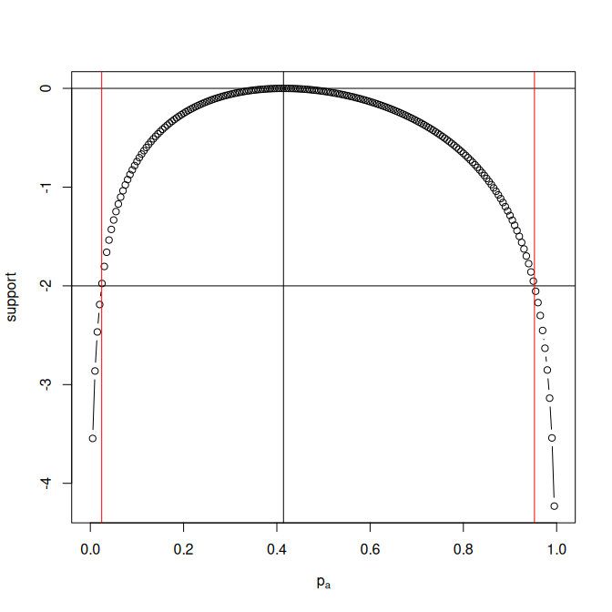

A support function for a>b>a

```r
a <- seq(from = 0, by = 0.005, to = 1)
S <- function(a){log(a * (1 - a) / ((1 + a) * (3 - 2 * sqrt(2))))}
plot(a, S(a), type = 'b',xlab=expression(p[a]),ylab="support")
abline(h = c(0, -2))
abline(v = c(0.02438102, 0.9524271), col = 'red')
abline(v = sqrt(2) - 1)
```

## Fisher information

If we have two clones of $a$ and a singleton $b$, then there are three possible rank statistics: (i), $a\succ a\succ b$ with probability $\frac{2a^2}{1+a}$; (ii), $a\succ b\succ a$, with $\frac{2a(1-a)}{(1+a)}$, (iii), $b\succ a\succ a$ at $\frac{1-a}{1+a}$. Likelihood functions for these order statistics are given in the figure below. It can be shown that the Fisher information for such observations is

$$\begin{equation}
\mathcal{I}(a)=2\frac{1+a+a^2}{a(1-a)(1+a)^2}
\end{equation}$$

which has a minimum of about $6.21$ at at about $a=0.522$. We can compare this with the Fisher information matrix ${\mathcal I}$, for the case of three distinct runners $a,b,c$, evaluated at its minimum of $p_a=p_b=p_c=\frac{1}{3}$. If we observe the complete order statistic, $\left|{\mathcal I}\right| =\frac{1323}{16}\simeq 82.7$; if we observe just the winner, $\left|{\mathcal I}\right|=27$, and if we observe just the loser we have $\left|{\mathcal I}\right|=\frac{16875}{256}\simeq 65.9$. A brief discussion is given at `inst/fisher_inf_PL3.Rmd`.

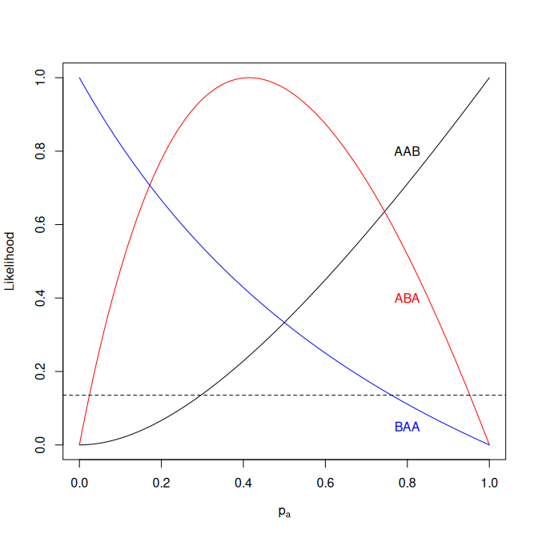

Support functions for observations a>a>b, a>b>a and b>a>a. Horizontal dotted line represents two units of support

```r
f_aab <- function(a){a^2 / (1 + a)}
f_aba <- function(a){a * (1 - a) / (1 + a)}
f_baa <- function(a){(1 - a) / (1 + a)}
p <- function(f, ...){
  a <- seq(from = 0, by = 0.005, to = 1)
  points(a, f(a) / max(f(a)), ...)
  }
plot(0:1, 0:1, xlab = expression(p[a]), ylab = "Likelihood", type = "n")
p(f_aab, type = "l", col = "black")
p(f_aba, type = "l", col = "red")
p(f_baa, type = "l", col = "blue")
text(0.8,0.8,"AAB")
text(0.8,0.4,"ABA",col="red")
text(0.8,0.05,"BAA",col="blue")
abline(h = exp(-2), lty = 2)
```

## Nonfinishers

If we allow non-finishers—that is, a subset of competitors who are beaten by all the ranked competitors ((Turner et al. 2020) call this a *top $n$ ranking*), there is another nontrivial order statistic, viz $a\succ b\succ\left\lbrace a,b\right\rbrace$ [thus one of the two $a$’s won, one of the $b$’s came second, and one of each of $a$ and $b$ failed to finish]. Now

$$\begin{equation}
\mathcal{L}(a)=
\frac{a}{2a+2b}\cdot
\frac{b}{ a+2b}\propto\frac{a(1-a)}{2-a}
\end{equation}$$

(see how the likelihood function is actually simpler than for the complete order statistic). The evaluate would be $2-\sqrt{2}\simeq 0.586$:

```r
maxp(ordervec2supp3(c("a", "b"), nonfinishers=c("a", "b")))
```

```
##         a         b
## 0.5857892 0.4142108
```

The Fisher information for such observations has a minimum of $\frac{68}{9}\simeq 7.56$ at $a=\frac{1}{2}$. An inference problem for a dataset including nonfinishers will be given below.

# An alternative to the Mann-Whitney test using generalized Plackett-Luce likelihood

The ideas presented above can easily be extended to arbitrarily large numbers of competitors, although the analytical expressions tend to be intractable and numerical methods must be used. All results and datasets presented here are maintained under version control and available at `https://github.com/RobinHankin/hyper2`. Given an order statistic of the type considered above, the Mann-Whitney-Wilcoxon test (Mann and Whitney 1947, wilcoxon1945) assesses a null of identity of underlying distributions (Ahmad 1996). Consider the chorioamnion dataset (Hollander, Wolfe, and Chicken 2013), used in `wilcox.test.Rd`:

```r
x <- c(0.80, 0.83, 1.89, 1.04, 1.45, 1.38, 1.91, 1.64, 0.73, 1.46)
y <- c(1.15, 0.88, 0.90, 0.74, 1.21)
```

Here we see a measure of permeability of the human placenta at term (`x`) and between 3 and 6 months’ gestational age (`y`). The order statistic is straightforward to calculate:

```r
names(x) <- rep("x", length(x))
names(y) <- rep("y", length(y))
(os <- names(sort(c(x, y))))
```

```
##  [1] "x" "y" "x" "x" "y" "y" "x" "y" "y" "x" "x" "x" "x" "x" "x"
```

Then object `os` is converted to a `hyper3` object, again with `ordervec2supp3()`, which may be assessed using the Method of Support:

```r
Hxy <- ordervec2supp3(os)
equalp.test(Hxy)
```

```
##
##  Constrained support maximization
##
## data:  Hxy
## null hypothesis: x = y
## null estimate:
##   x   y
## 0.5 0.5
## (argmax, constrained optimization)
## Support for null:  -27.89927 + K
##
## alternative hypothesis:  sum p_i=1
## alternative estimate:
##         x         y
## 0.2401539 0.7598461
## (argmax, free optimization)
## Support for alternative:  -26.48443 + K
##
## degrees of freedom: 1
## support difference = 1.414837
## p-value: 0.09253716
```

Above, we use generic function `equalp.test()` to test the null that the permeability of the two groups both have Bradley-Terry strength of $0.5$. We see a $p$ value of about 0.09; compare 0.25 from `wilcox.test()`. However, observe that the `hyper3` likelihood approach gives more information than Wilcoxon’s analysis: Firstly, we see that the maximum likelihood estimate for the Bradley-Terry strength of `x` is about 0.24, considerably less than the null of 0.5; further, we may plot a support curve for this dataset, given in the figure below.

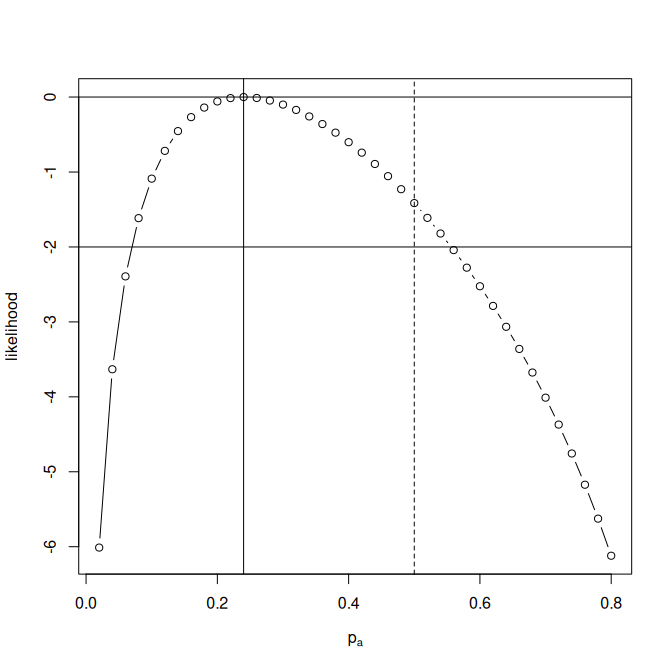

A support function for the Bradley-Terry strength of permeability at term. The evaluate of 0.24 is shown; and the two-units-of support credible interval, which does not exclude the null of strength 0.5 (dotted line), is also shown

```r
a <- seq(from = 0.02, to = 0.8, len = 40)
L <- sapply(a, function(p){loglik(p, Hxy)})
plot(a, L - max(L), type = 'b',xlab=expression(p[a]),ylab="likelihood")
abline(h = c(0, -2))
abline(v = c(0.24))
abline(v=c(0.5), lty=2)
```

## A generalization of the Mann-Whitney test using generalized Plackett-Luce likelihood

The ideas presented above may be extended to more than two types of competitors. Consider the following table, drawn from the men’s javelin, 2020 Olympics:

```r
javelin_table
```

```
## An attemptstable:
##           throw1 throw2 throw3 throw4 throw5 throw6
## Chopra     87.03  87.58  76.79      X      X  84.24
## Vadlejch   83.98      X      X  82.86  86.67      X
## Vesely     79.73  80.30  85.44      X  84.98      X
## Weber      85.30  77.90  78.00  83.10  85.15  75.72
## Nadeem     82.40      X  84.62  82.91  81.98      X
## Katkavets  82.49  81.03  83.71  79.24      X      X
## Mardare    81.16  81.73  82.84  81.90  83.30  81.09
## Etelatalo  78.43  76.59  83.28  79.20  79.99  83.05
```

Thus Chopra threw 87.03m on his first throw, 87.58m on his second, and so on. No-throws, ignored here, are indicated with an `X`. We may convert this to a named vector with elements being the throw distances, and names being the competitors, using `attemptstable2supp3()`:

```r
javelin_vector <- attemptstable2supp3(javelin_table,
       decreasing = TRUE, give.supp = FALSE)
options(width = 60)
javelin_vector
```

```
##    Chopra    Chopra  Vadlejch    Vesely     Weber     Weber
##     87.58     87.03     86.67     85.44     85.30     85.15
##    Vesely    Nadeem    Chopra  Vadlejch Katkavets   Mardare
##     84.98     84.62     84.24     83.98     83.71     83.30
## Etelatalo     Weber Etelatalo    Nadeem  Vadlejch   Mardare
##     83.28     83.10     83.05     82.91     82.86     82.84
## Katkavets    Nadeem    Nadeem   Mardare   Mardare   Mardare
##     82.49     82.40     81.98     81.90     81.73     81.16
##   Mardare Katkavets    Vesely Etelatalo    Vesely Katkavets
##     81.09     81.03     80.30     79.99     79.73     79.24
## Etelatalo Etelatalo     Weber     Weber    Chopra Etelatalo
##     79.20     78.43     78.00     77.90     76.79     76.59
##     Weber  Vadlejch    Nadeem  Vadlejch    Chopra    Vesely
##     75.72        NA        NA        NA        NA        NA
##    Chopra Katkavets  Vadlejch    Vesely    Nadeem Katkavets
##        NA        NA        NA        NA        NA        NA
```

```r
javelin <- ordervec2supp3(v = names(javelin_vector)[!is.na(javelin_vector)])
```

Above, object `javelin` is a `hyper3` likelihood function, so one has access to the standard likelihood-based methods, such as finding and displaying the maximum likelihood estimate, shown in the figure below.

```r
(mj <- maxp(javelin))
```

```
##    Chopra Etelatalo Katkavets   Mardare    Nadeem  Vadlejch
##    0.0930    0.0482    0.0929    0.1173    0.1730    0.3206
##    Vesely     Weber
##    0.1140    0.0409
```

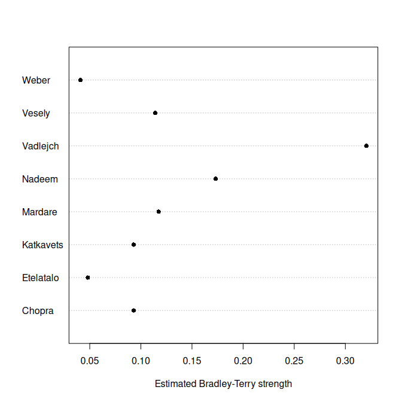

Maximum likelihood estimate for javelin throwers’ Bradley-Terry strengths

```r
dotchart(mj, pch = 16,xlab="Estimated Bradley-Terry strength")
```

From this, we see that Vadlejch has the highest estimated Bradley-Terry strength, but further analysis with `equalp.test()` reveals that there is no strong evidence in the dataset to reject the hypothesis of equal competitive strength ($p=0.26$), or that Vadlejch has a strength higher than the null value of $\frac{1}{8}$ ($p=0.1$).

A particularly attractive feature of this analysis is that the Bradley-Terry strengths have direct operational significance: If two competitors, say Vadlejch and Vesely, were to throw a javelin, then we would estimate the probability that Vadlejch would throw further than Vesely at $\displaystyle p_{\mbox{Vad}}/\left(p_{\mbox{Vad}} + p_{\mbox{Ves}}\right)\simeq 0.74$. Indeed, from a training or selection perspective we might follow Hankin (2017) and observe that log-contrasts (O’Hagan and Forster 2004) appear to have approximately Gaussian likelihood functions for observations of the type considered here. Profile log-likelihood curves for log-contrasts are easily produced by the package, below.

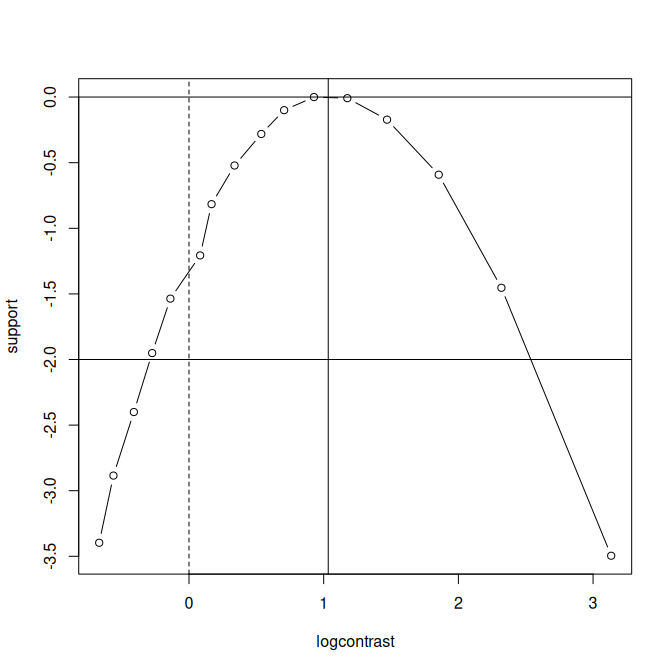

Profile likelihood for log-contrast as per the text. Null indicated with a dotted line, and two-units-of-support limit indicated with horizontal lines; thus the null is not rejected

We see that the credible range for $\log\left(p_{\mbox{Vad}}/ p_{\mbox{Ves}}\right)$ includes zero and we have no strong evidence for these athletes having different (Bradley-Terry) strengths.

# Formula 1 motor racing: The Constructors’ Championship

```r
constructor_2021_table[, 1:9]
```

```
##    Constructor BHR EMI POR ESP  MON AZE FRA STY
## 1         Merc   1   2   1   1    7  12   2   2
## 2         Merc   3 Ret   3   3  Ret  15   4   3
## 3         RBRH   2   1   2   2    1   1   1   1
## 4         RBRH   5  11   4   5    4  18   3   4
## 5      Ferrari   6   4   6   4    2   4  11   6
## 6      Ferrari   8   5  11   7 DNSP   8  16   7
## 7           MM   4   3   5   6    3   5   5   5
## 8           MM   7   6   9   8   12   9   6  13
## 9           AR  13   9   7   9    9   6   8   9
## 10          AR Ret  10   8  17   13 Ret  14  14
## 11         ATH   9   7  10  10    6   3   7  10
## 12         ATH  17  12  15 Ret   16   7  13 Ret
## 13         AMM  10   8  13  11    5   2   9   8
## 14         AMM  15  15  14  13    8 Ret  10  12
## 15          WM  14 Ret  16  14   14  16  12  17
## 16          WM  18 Ret  18  16   15  17  18 Ret
## 17        ARRF  11  13  12  12   10  10  15  11
## 18        ARRF  12  14 Ret  15   11  11  17  15
## 19          HF  16  16  17  18   17  13  19  16
## 20          HF Ret  17  19  19   18  14  20  18
```

Above, we see that Mercedes (“`Merc`”) came first and third at Bahrain (`BHR`); and came second and retired at Emilia Romagna (`EMI`); full details of the notation and conventions are given in the package at `constructor.Rd`. The identity of the driver is viewed as inadmissible information and indeed may change during a season. Alternatively, we may regard the driver and the constructor as a joint entity, with the constructor’s ability to attract and retain a skilled driver being part of the object of inference. The associated generalized Plackett-Luce `hyper3` object is easily constructed using package idiom, in this case `ordertable2supp3()`, and we may use this to assess the Plackett-Luce strengths of the constructors:

```r
const2020 <- ordertable2supp3(constructor_2020_table)
const2021 <- ordertable2supp3(constructor_2021_table)
options(digits=4)
```

```
maxp(const2020)
##    ARRF     ATH Ferrari      HF    Merc      MR       R
## 0.04530 0.06807 0.06063 0.02623 0.37783 0.10026 0.09767
##    RBRH  RPBWTM      WM
## 0.12072 0.08055 0.02273
```

```
maxp(const2021)
##     AMM      AR    ARRF     ATH Ferrari      HF    Merc
## 0.05942 0.07543 0.06238 0.05611 0.16939 0.02023 0.19395
##      MM    RBRH      WM
## 0.14126 0.18334 0.03848
```

```r
H <- (
      psubs(constructor_2020, "Merc", "Merc2020") +
      psubs(constructor_2021, "Merc", "Merc2021")
     )
```

Above, we use generic function `psubs()` to change the name of Mercedes from `Merc` to `Merc2020` and `Merc2021` respectively. Note the use of `+` to represent addition of log-likelihoods, corresponding to the assumption of conditional independence of results. The null would be simply that the strengths of `Merc2020` and of `Merc2021` are identical. Package idiom would be to use generic function `samep.test()`:

```r
options(digits = 4)
samep.test(H, c("Merc2020", "Merc2021"))
```

```
##
##  Constrained support maximization
##
## data:  H
## null hypothesis: Merc2020 = Merc2021
## null estimate:
##      AMM       AR     ARRF      ATH  Ferrari       HF
##  0.04239  0.05413  0.04677  0.04374  0.07568  0.02323
## Merc2020 Merc2021       MM       MR        R     RBRH
##  0.13903  0.13903  0.09016  0.07944  0.07475  0.10024
##   RPBWTM       WM
##  0.06235  0.02905
## (argmax, constrained optimization)
## Support for null:  -1189 + K
##
## alternative hypothesis:  sum p_i=1
## alternative estimate:
##      AMM       AR     ARRF      ATH  Ferrari       HF
##  0.03766  0.04824  0.04333  0.04060  0.07036  0.02132
## Merc2020 Merc2021       MM       MR        R     RBRH
##  0.23135  0.09216  0.07893  0.07973  0.07455  0.09322
##   RPBWTM       WM
##  0.06177  0.02679
## (argmax, free optimization)
## Support for alternative:  -1184 + K
##
## degrees of freedom: 1
## support difference = 4.722
## p-value: 0.002119
```

Above, we see strong evidence for a real decrease in the strength of the Mercedes team from 2020 to 2021, with $p=0.002$.

# Conclusions and further work

Plackett-Luce likelihood functions for rank datasets have been generalized to impose identity of Bradley-Terry strengths for certain groups; the preferred interpretation is a running race in which the competitors are split into equivalence classes of clones. Implementing this in `R` is accomplished via a `C++` back-end making use of the `STL` “map” class which offers efficiency advantages, especially for large objects.

New likelihood functions for simple cases with three or four competitors were presented, and extending to larger numbers furnishes a generalization of the Mann-Whitney-Wilcoxon test that offers a specific alternative (Bradley-Terry strength) with a clear operational definition. Further generalizations allow the analysis of more than two groups, here applied to Olympic javelin throw distances. Generalized Plackett-Luce likelihood functions were used to assess the Grand Prix constructors’ championship and a reasonable null. Specifically, the hypothesis that the strength of the Mercedes team remained unchanged between 2020 and 2021 was tested and rejected.

Draws are not considered in the present work but in principle may be accommodated, either using likelihoods comprising sums of Plackett-Luce probabilities (Hankin 2017); or the introduction of a reified draw entity (Hankin 2010).

Further work might include a systematic comparison between `hyper3` approach and the Mann-Whitney-Wilcoxon test, including the characterisation of the power function of both tests. The package could easily be extended to allow non-integer multiplicities, which might prove useful in the context of reified Bradley Terry techniques (Hankin 2020).

# References

Ahmad, I. A. 1996. “A Class of Mann-Whitney-Wilcoxon Type Statistics.” *The American Statistician* 50 (4): 324–27.

Allison, P. D., and N. A. Christakis. 1994. “Logit Models for Sets of Ranked Items.” *Sociological Methodology* 24: 199–228.

Baker, S. G. 1994. “The Multinomial-Poisson Transformation.” *The Statistician* 43 (4): 495–504.

Codling, S. 2017. *Speed Read F1*. Motorbooks.

Core Team. 2023. *: A Language and Environment for Statistical Computing*. Vienna, Austria: Foundation for Statistical Computing. https://www.R-project.org/.

Edwards, A. W. F. 1972. *Likelihood*. John Hopkins University Press.

Firth, David. 2005. “Bradley-Terry Models in R.” *Journal of Statistical Software* 12 (1).

Hankin, R. K. S. 2010. “A Generalization of the Dirichlet Distribution.” *Journal of Statistical Software* 33 (11): 1–18. https://doi.org/10.18637/jss.v033.i11.

———. 2017. “Partial Rank Data with the `hyper2` Package: Likelihood Functions for Generalized Bradley-Terry Models.” *The R Journal* 9 (2): 429–39.

———. 2020. “A Generalization of the Bradley-Terry Model for Draws in Chess with an Application to Collusion.” *Journal of Economic Behavior and Organization* 180: 325–33.

———. 2022. *: Non-Ordered Vectors*. https://github.com/RobinHankin/disordR.

———. 2024. “Generalized Plackett-Luce Likelihoods.” *Journal of Statistical Software* 109 (8). https://doi.org/10.18637/jss.v109.i08.

Hollander, M., D. A. Wolfe, and E. Chicken. 2013. *Nonparametric Statistical Methods*. 3rd ed. John Wiley. https://doi.org/https://doi.org/10.1002/9781119196037.

Hunter, D. R. 2004. “MM Algorithms for Generalized Bradley-Terry Models.” *The Annals of Statistics* 32 (1): 384–406.

Mann, H. B., and D. R. Whitney. 1947. “On a Test of Whether One of Two Random Variables Is Stochastically Larger Than the Other.” *Ann. Math. Statist.* 18 (1): 50–60. https://doi.org/https://doi.org/10.1214/aoms/1177730491.

Maystre, L. 2022. *: Inference Algorithms for Models Based on Luce’s Choice Axiom*. https://github.com/lucasmaystre/choix.

Mollica, C., and L. Tardella. 2014. “Epitope Profiling via Mixture Modeling of Ranked Data.” *Statistics in Medicine* 33: 3738–58.

O’Hagan, A., and J. Forster. 2004. *Kendall’s Advanced Theory of Statistics, Volume 2B: Bayesian Inference*. 2nd ed. John Wiley & Sons. https://doi.org/https://doi.org/10.1111/j.1467-985x.2004.00347_15.x.

Plackett, R. L. 1975. “The Analysis of Permutations.” *Applied Statistics* 24: 193–202.

Turner, H. L., and David Firth. 2012. “Bradley-Terry Models in : The Package.” *Journal of Statistical Software* 48 (9): 1–21. https://doi.org/10.18637/jss.v048.i09.

Turner, H. L., Jacob van Etten, David Firth, and Ioannis Kosmidis. 2020. “Modelling Rankings in : The Package.” *Computational Statistics* 35: 1027–57. https://doi.org/10.1007/s00180-020-00959-3.